# Statistique Descriptive

Kossi Tonyi Wobubey ABOTSI

default

[output not shown]

### Traitement des données

```r
# Read data from the Excel file
data <- read_excel("data_send.xlsx")
#Selection des colonnes utile
data = data  %>% dplyr::select(college:classe,`taille_cm`: gender,sb:pmvpa,time,CA:`ecart_MVPA`)

#Renommage des colonnes
colnames(data)[23:24] = c("CSP_père","CSP_mère")

#Caste
data$weight_kg = as.double(data$weight_kg)
data$taille_cm = as.double(data$taille_cm)
data$age = as.integer(data$age)
data$time = as.double(data$time)

#Ajout de colonne des IMC
data$IMC_kg_m2 <- data$weight_kg / (data$taille_cm * 10^-2)^2

# Ajout d'une nouvelle colonne "IPS_categorie"
data$IPS_categorie <- ifelse(data$IPS < 89, "Faible",
                             ifelse(data$IPS >= 90 & data$IPS <= 114, "Moyenne", "Élevée"))

#Résolution du problème de facteur double
data$gender = ifelse(data$gender != 'M' & data$gender != 'F', 'M', data$gender)

data
```

```
## # A tibble: 462 × 28
##    college classe taille_cm weight_kg   age gender    sb   lpa   mpa   vpa psb
##    <chr>   <chr>      <dbl>     <dbl> <int> <chr>  <dbl> <dbl> <dbl> <dbl> <chr>
##  1 aigle   3.P          157        55    15 F       26.3  4.83  21.2  2.33 47,8…
##  2 aigle   3.P          178        61    14 M       14    8.33  28    4    25,4…
##  3 aigle   3.P          170        75    15 M       20.3  7.33  21.8  5    36,9…
##  4 aigle   3.P          153        68    15 F       26.2  7.33  18.7  2.83 47,5…
##  5 aigle   3.P          181        95    15 M       12.2 12.3   22.3  6.17 22,1…
##  6 aigle   3.P          164        51    15 F       20.5  6.5   20.3  4.83 37,2…
##  7 aigle   3.P          170        63    15 M       21.2  5.33  21.5  5.33 38,4…
##  8 aigle   3.P          167        55    15 M       14.8  7.67  22.3  7.33 26,9…
##  9 aigle   3.P          167        52    15 M        3    2     28   19    5,45…
## 10 aigle   3.P          158        69    15 F       18    8.67  25    3    32,7…
## # ℹ 452 more rows
## # ℹ 17 more variables: pla <chr>, pmpa <chr>, pvpa <chr>, mvpa <dbl>,
## #   pmvpa <chr>, time <dbl>, CA <dbl>, activites <chr>, IPS <dbl>,
## #   cat_IPS <chr>, Geographie <chr>, CSP_père <chr>, CSP_mère <chr>,
## #   moyenne_MVPA_classe <dbl>, ecart_MVPA <dbl>, IMC_kg_m2 <dbl>,
## #   IPS_categorie <chr>
```

### 1) Les écarts de MVPA entre filles et garçons selon les CA (CA1, CA2, CA3, CA4)

#### Selection des colonnes importantes

```r
#Selection des colonnes importantes
data_1 = data %>%
  dplyr::select(gender,ecart_MVPA,CA)


#Assurons nous que le types des variables qualitatives sont des facteurs
data_1$gender = as.factor(data_1$gender)
data_1$CA = as.factor(data_1$CA)

data_1
```

```
## # A tibble: 462 × 3
##    gender ecart_MVPA CA
##    <fct>       <dbl> <fct>
##  1 F          -5.28  3
##  2 M           3.55  3
##  3 M          -1.78  3
##  4 F          -7.62  3
##  5 M           1.38  3
##  6 F          -1.12  3
##  7 M          -0.615 3
##  8 M           3.38  3
##  9 M          20.9   3
## 10 F          -0.782 3
## # ℹ 452 more rows
```

```r
#write_xlsx(data_1, "data_gpt.xlsx")
```

#### Représentation des données et Ananlyse graphique de l’interaction

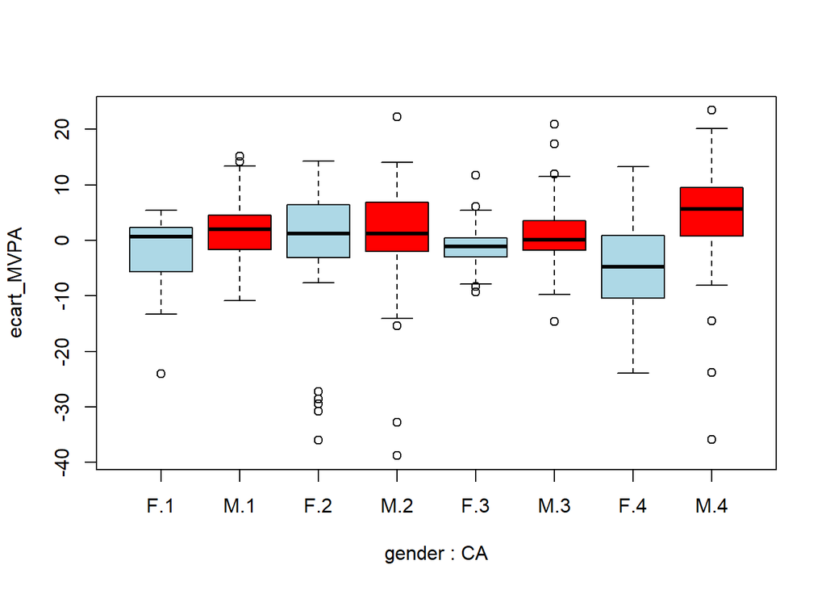

```r
boxplot(ecart_MVPA~gender*CA,data=data_1,col=c(rep('lightblue',1),rep('red',1)))
```

On remarque que généralement le mvpa des est supérieur dans les CA 1 et 2 que dans les CA 3 et 4.

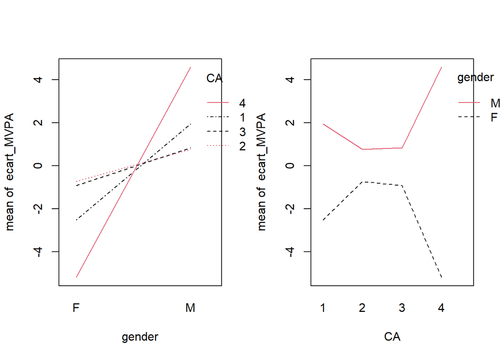

```r
par(mfrow=c(1,2))
with(data_1, interaction.plot(gender,CA,ecart_MVPA,col=1:2))
with(data_1, interaction.plot(CA,gender,ecart_MVPA,col=1:4))
```

Les profils ne sont pas parallèles. Nous constatons que les modalités **2-F** et **4-F** sont éloigné de la position qu’elle auraient dû occuper si les profils étaient exactement parallèles. Les filles dans le CA 2 sont propice à un mvpa élevé. L’effet de ma variable genre sur le mvpa depend du CA.Donc ce graphique suggère une interraction entre CA et Sexe.

Maintenant est ce que cette interaction observée est significative ?

#### Modèle :

```r
table(data_1$gender,data_1$CA)
```

```
##
##       1   2   3   4
##   F  20  53  49  98
##   M  26  51  54 111
```

Dans notre cas , le nombre d’observation diffère selon le croisement des modalités de **CA** et **gender**. Donc nos données sont **déséquilibrées on ne peut donc pas estimés de manières indépendantes l’effet d’un facteur ou interactions des autres**. Lors de la décomposition de la variabilité, ce déséquilibre a un impact sur le calcul des différentes sommes de carrés, et par suite sur les tests qui sont construits. Il est donc nécessaire de choisir de quel type de somme de carré seront utilisés (type I, typeII, ou type III). Pour construire notre modèle j’utililise la somme des carré de type II avec la contrainte de somme des coefficients nulle. Ce choix est motivé par le fait que l’odre des facteurs n’a aucun sens dans l’objectif de mon sujet (typeI). L’ANOVA de type III pose des problèmes au niveaux de l’interprétation des résultats de test, surtout en ce qui concerne les effets principaux.

### Analyse des résidus

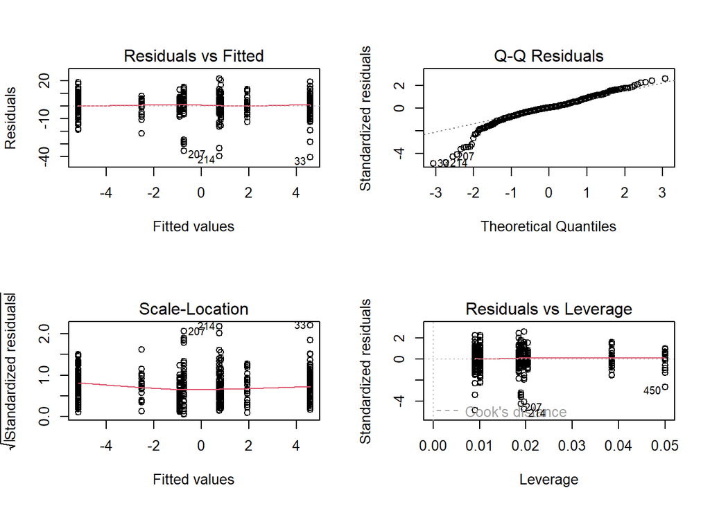

```r
# Ajustement du modèle ANOVA
modele_complet <- aov(ecart_MVPA ~ gender + CA + gender:CA,contrasts = list(gender = contr.sum,CA = contr.sum),data = data_1)
par(mfrow = c(2,2))
plot(modele_complet)
```

```r
# Diagnostic des résidus
# Test de normalité des résidus
#residus <- residuals(modele_complet)
#shapiro_test <- shapiro.test(residus)
#print(shapiro_test)

# Test d'homogénéité des variances
#levene_test <- leveneTest(mvpa ~ gender*CA, data = data_1)
#print(levene_test)
```

Le graphique en haut à gauche, qui représente en abscisse les valeurs prédites et en ordonnée les résidus permet de vérifier que la variance des résidus est similaire dans tous les groupes. Le graphique du QQ-plot, permet de vérifier que l’hypothèse de normalité des résidus est raisonnable.

Avec ces hypothèses validées nous pouvons regarder les tests.

### Les tests du modèle complet et des différents effets

```r
Anova(modele_complet,type='II')
```

```
## Anova Table (Type II tests)
##
## Response: ecart_MVPA
##            Sum Sq  Df F value    Pr(>F)
## gender     3585.2   1 51.5200 2.911e-12 ***
## CA            6.4   3  0.0307    0.9927
## gender:CA  1738.0   3  8.3252 2.122e-05 ***
## Residuals 31592.8 454
## ---
## Signif. codes:  0 '***' 0.001 '**' 0.01 '*' 0.05 '.' 0.1 ' ' 1
```

Pour le test de comparaison du modèle avec interaction (modèle complet) et du modèle sans interaction, on a les hypothèses :

- H0 : Il n’y a pas d’interaction.
- H1 : il y a des interactions.

On observe une p-valeur inférieur au seuil de 5% donc les interactions entre le genre et CA sont significativement différent de zéro.

### Test post hoc

```r
lsmeans_results <- lsmeans(modele_complet, pairwise ~ gender:CA, adjust='Tukey')
summary(lsmeans_results,infer = c(TRUE, TRUE))
```

```
## $lsmeans
##  gender CA lsmean    SE  df lower.CL upper.CL t.ratio p.value
##  F      1  -2.518 1.865 454    -6.18     1.15  -1.350  0.1777
##  M      1   1.937 1.636 454    -1.28     5.15   1.184  0.2371
##  F      2  -0.731 1.146 454    -2.98     1.52  -0.638  0.5241
##  M      2   0.759 1.168 454    -1.54     3.05   0.650  0.5160
##  F      3  -0.916 1.192 454    -3.26     1.43  -0.769  0.4426
##  M      3   0.831 1.135 454    -1.40     3.06   0.732  0.4645
##  F      4  -5.186 0.843 454    -6.84    -3.53  -6.154  <.0001
##  M      4   4.579 0.792 454     3.02     6.13   5.783  <.0001
##
## Confidence level used: 0.95
##
## $contrasts
##  contrast      estimate   SE  df lower.CL upper.CL t.ratio p.value
##  F CA1 - M CA1  -4.4548 2.48 454  -12.010    3.100  -1.795  0.6235
##  F CA1 - F CA2  -1.7873 2.19 454   -8.454    4.879  -0.816  0.9922
##  F CA1 - M CA2  -3.2771 2.20 454   -9.979    3.425  -1.489  0.8132
##  F CA1 - F CA3  -1.6020 2.21 454   -8.342    5.138  -0.724  0.9963
##  F CA1 - M CA3  -3.3490 2.18 454   -9.998    3.300  -1.534  0.7888
##  F CA1 - F CA4   2.6681 2.05 454   -3.565    8.901   1.304  0.8973
##  F CA1 - M CA4  -7.0966 2.03 454  -13.267   -0.926  -3.502  0.0118
##  M CA1 - F CA2   2.6674 2.00 454   -3.415    8.750   1.335  0.8849
##  M CA1 - M CA2   1.1776 2.01 454   -4.944    7.299   0.586  0.9990
##  M CA1 - F CA3   2.8527 2.02 454   -3.311    9.016   1.409  0.8527
##  M CA1 - M CA3   1.1058 1.99 454   -4.958    7.169   0.555  0.9993
##  M CA1 - F CA4   7.1229 1.84 454    1.519   12.727   3.871  0.0031
##  M CA1 - M CA4  -2.6418 1.82 454   -8.176    2.893  -1.454  0.8314
##  F CA2 - M CA2  -1.4898 1.64 454   -6.473    3.493  -0.910  0.9850
##  F CA2 - F CA3   0.1853 1.65 454   -4.849    5.220   0.112  1.0000
##  F CA2 - M CA3  -1.5617 1.61 454   -6.473    3.350  -0.968  0.9786
##  F CA2 - F CA4   4.4555 1.42 454    0.124    8.787   3.132  0.0387
##  F CA2 - M CA4  -5.3092 1.39 454   -9.550   -1.068  -3.812  0.0039
##  M CA2 - F CA3   1.6751 1.67 454   -3.406    6.757   1.004  0.9738
##  M CA2 - M CA3  -0.0719 1.63 454   -5.032    4.888  -0.044  1.0000
##  M CA2 - F CA4   5.9453 1.44 454    1.559   10.331   4.128  0.0011
##  M CA2 - M CA4  -3.8194 1.41 454   -8.117    0.478  -2.707  0.1232
##  F CA3 - M CA3  -1.7470 1.65 454   -6.759    3.265  -1.061  0.9643
##  F CA3 - F CA4   4.2701 1.46 454   -0.174    8.715   2.926  0.0699
##  F CA3 - M CA4  -5.4946 1.43 454   -9.851   -1.138  -3.840  0.0035
##  M CA3 - F CA4   6.0171 1.41 454    1.712   10.322   4.256  0.0007
##  M CA3 - M CA4  -3.7476 1.38 454   -7.962    0.467  -2.708  0.1229
##  F CA4 - M CA4  -9.7647 1.16 454  -13.286   -6.244  -8.445  <.0001
##
## Confidence level used: 0.95
## Conf-level adjustment: tukey method for comparing a family of 8 estimates
## P value adjustment: tukey method for comparing a family of 8 estimates
```

|  | CA1 | CA2 | CA3 | CA4 |
| --- | --- | --- | --- | --- |
| Ecart entre fille et gaçon des ecarts à la moyenne de mvpa de chaque classe | -4.4548 | -1.4898 | -1.7470 | -9.7647 |
| Intervalle de confiance | -12.010 à 3.100 | -6.4730 à 3.493 | -6.759 à 3.265 | -13.286 à -6.244 |
| P-valeur | 0.6235 | 0.9850 | 0.96 | 0.000 |

### Diagramme en barre de la différence des ecart_mvpa des Filles et Garçons

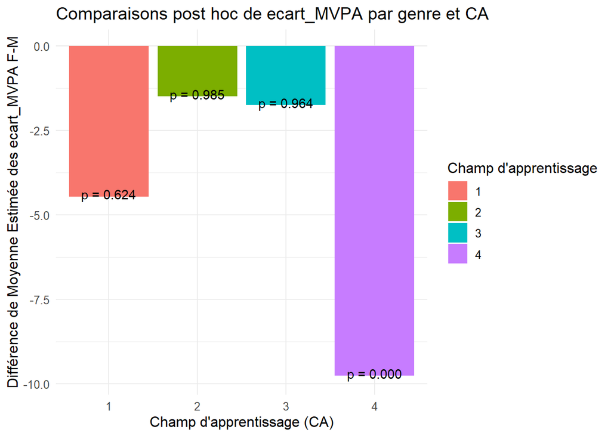

```r
# Calcul des moyennes marginales estimées et des comparaisons post hoc avec correction de Tukey
summary_data <- summary(lsmeans_results$contrasts)

# Filtrer les contrastes pour ne garder que ceux entre F et M au sein de chaque catégorie d'âge (CA)
plot_data <- summary_data[summary_data$contrast %in% c("F CA1 - M CA1", "F CA2 - M CA2", "F CA3 - M CA3", "F CA4 - M CA4"), ]

# Préparation des données pour le graphique
plot_data <- as.data.frame(plot_data[c("contrast", "estimate", "p.value")])
names(plot_data) <- c("Contrast", "Estimate", "P_Value")

# Extraire la catégorie d'âge à partir du nom du contraste
plot_data$CA <- sub(".*CA([0-9]+).*", "\\1", plot_data$Contrast)

# Déterminer le décalage pour les étiquettes textuelles
max_estimate <- max(plot_data$Estimate) * 0.05

# Création du barplot avec légende pour les catégories d'âge
p <- ggplot(plot_data, aes(x = CA, y = Estimate, fill = CA)) +
  geom_bar(stat = "identity", position = position_dodge()) +
  geom_text(aes(label = sprintf("p = %.3f", P_Value),
                y = Estimate + max_estimate),  # Utilisation de la variable calculée hors de aes()
            position = position_dodge(width = 0.99), vjust = 0) +
  labs(title = "Comparaisons post hoc de ecart_MVPA par genre et CA",
       x = "Champ d'apprentissage (CA)",
       y = "Différence de Moyenne Estimée des ecart_MVPA F-M",
       fill = "Champ d'apprentissage") +  # Ajout de la légende
  theme_minimal() +
  theme(text = element_text(size=12))

print(p)
```

On remarque un écart significatif entre les écarts de mvpa à la moyenne de chaque classe des filles et garcons dans le champs 4 avec une p-valeur inférieur au seuil de 5%. Donc la moyenne des écarts à la moyenne de chaque classe des garçons est plus élevé dans le champs 4 que celui des filles. Dans les autres champs d’apprentissage cet écart de la moyenne des écart n’est pas significatif.

### Les tailles d’effets (Omega carré) : mesure la force de l’effet observé d’un facteur(écart entre la vrai valeur et l’hypothèse nulle)

L’omega carré est une mésure de taille d’effet. Il ajuste la proportion de variance expliquée en prenant en compte le bias potentielle dû à l’échantillonnage ce qui est adapté dans notre cas du au déséquilibre de notre plan. On vas utiliser l’omega carré partiel qui est une estimation plus précise de taille d’effet :

```r
anova_typeII = Anova(modele_complet,type = "II")
omega_squared_values = omega_squared(anova_typeII)
omega_squared_values
```

```
## # Effect Size for ANOVA (Type II)
##
## Parameter | Omega2 (partial) |       95% CI
## -------------------------------------------
## gender    |             0.10 | [0.06, 1.00]
## CA        |             0.00 | [0.00, 1.00]
## gender:CA |             0.05 | [0.02, 1.00]
##
## - One-sided CIs: upper bound fixed at [1.00].
```

- La taille d’effet pour le facteur gender est 0.1 ce qui signifie que 10% de la variance totale de la variable dépendante(ecart_mvpa) peut être attribuée à l’effet du genre.
- La taille d’effet pour le facteur CA est 0 ce qui signifie que 0% de la variance totale de la variable dépendante(ecart_mvpa) peut être attribuée à l’effet du CA.
- La taille d’effet pour l’intercation entre genre et CA est 0.05 ce qui signifie que 5% de la variance totale de la variable dépendante(ecart_mvpa) peut être attribuée à l’effet de l’interaction.

Les intervalle de confiance sont unilatéral.

#### Interprétation :

La taille d’effet du facteur genre est important ce qui montre que la différence observé entre les filles et garçons est à prendre en compte dans la pratique.

La taille d’effet de l’interaction est moyenne donc l’effet est modérément important ce qui a des implications pratiques (écart de mvpa entre les filles et garçons observé dans le champs 4 est à prendre en compte dans pratique car jugé importante).

### La puissance des test de significativité des facteurs (interaction)

La puissance statistique dans ce contexte fait réference à la probabilité de rejeter l’hypothèse nulle (pas d’effet du facteur) lorsqu’elle est fausse, c’est à dire la capacité de dtecter un effet réel.

Ici ce qui nous interresse c’est l’interaction car on cherche a connaitre ecart de mvpa entre fille et garçon selon le CA(comparaison des groupes suivant combinaison des deux facteurs genre et CA).

```r
taille_effet = omega_squared_values$Omega2_partial
f_square = taille_effet/(1-taille_effet)#utiliser car indépendant de la taille de l'échantillon.

nbr_modalite_interaction = length(unique(data_1$gender))*length(unique(data_1$CA))#Nombre total de modalité
effectif_groupe_moyen = nrow(data_1)/nbr_modalite_interaction

puissance = pwr.anova.test(nbr_modalite_interaction,f=sqrt(f_square[3]),sig.level = 0.05,power = NULL,n=effectif_groupe_moyen)

puissance
```

```
##
##      Balanced one-way analysis of variance power calculation
##
##               k = 8
##               n = 57.75
##               f = 0.2180971
##       sig.level = 0.05
##           power = 0.9479398
##
## NOTE: n is number in each group
```

Si on a en moyenne 57.75 effectifs par groupe j’ai 95% de chance de detecter un effet significatif de l’interaction.

### Taille d’échantillon requise pour détecter un effet avec une proba de 80% (interaction)

```r
taille_echantillon = pwr.anova.test(nbr_modalite_interaction,f=sqrt(f_square[3]),sig.level = 0.05,power = 0.8)
taille_echantillon
```

```
##
##      Balanced one-way analysis of variance power calculation
##
##               k = 8
##               n = 38.5997
##               f = 0.2180971
##       sig.level = 0.05
##           power = 0.8
##
## NOTE: n is number in each group
```

Avec donc un effectif de 39 par groupe on aurai 80% de chance de détecter un effet significatif de l’interaction.

Donc on voit clairement que les groupes F-CA1 et M-CA1 sont problematique. Mais on peut être sur de notre analyse du au p-valeur assez élevé très loi de 5%.

### 2) Les écarts de MVPA entre filles et garçons selon la catégorie d’IPS du collège (élevé, moyen, faible)

#### Selection des colonnes importantes

```r
#Selection des colonnes importantes
data_2 = data %>%
  dplyr::select(gender,ecart_MVPA,IPS_categorie)

#Assurons nous que le types des variables qualitatives sont des facteurs
data_2$gender = as.factor(data_2$gender)
data_2$IPS_categorie = as.factor(data_2$IPS_categorie)

data_2
```

```
## # A tibble: 462 × 3
##    gender ecart_MVPA IPS_categorie
##    <fct>       <dbl> <fct>
##  1 F          -5.28  Moyenne
##  2 M           3.55  Moyenne
##  3 M          -1.78  Moyenne
##  4 F          -7.62  Moyenne
##  5 M           1.38  Moyenne
##  6 F          -1.12  Moyenne
##  7 M          -0.615 Moyenne
##  8 M           3.38  Moyenne
##  9 M          20.9   Moyenne
## 10 F          -0.782 Moyenne
## # ℹ 452 more rows
```

### Effectifs par groupe :

```r
table(data_2$gender,data_2$IPS_categorie)
```

```
##
##     Élevée Faible Moyenne
##   F     93     48      79
##   M     89     44     109
```

#### Représentation des données et Ananlyse graphique de l’interaction

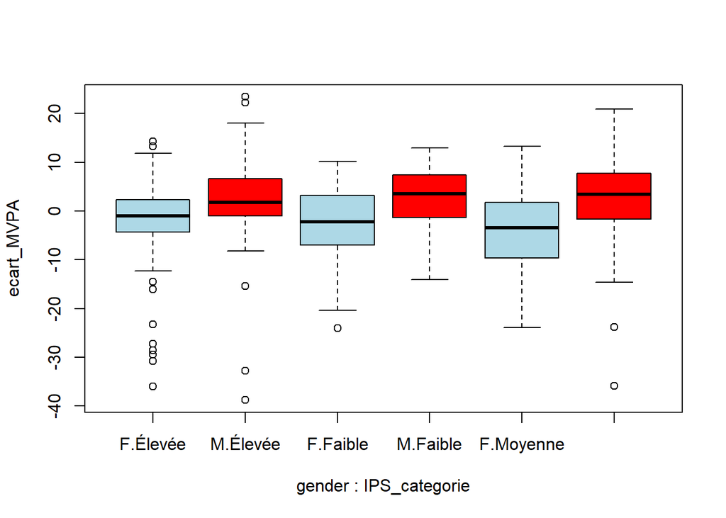

```r
boxplot(ecart_MVPA~gender*IPS_categorie,data=data_2,col=c(rep('lightblue',1),rep('red',1)))
```

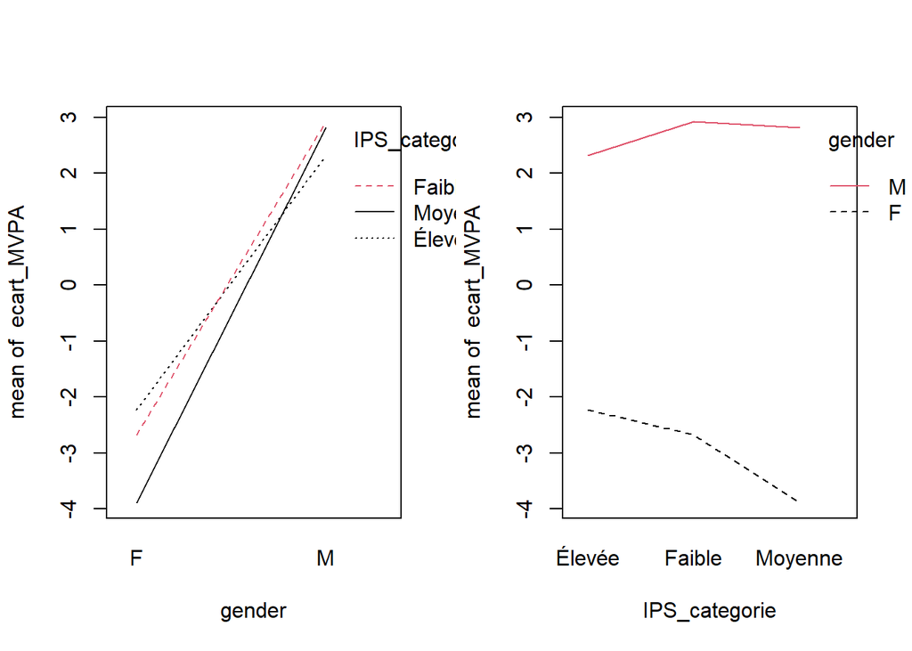

```r
par(mfrow=c(1,2))
with(data_2, interaction.plot(gender,IPS_categorie,ecart_MVPA,col=1:2))
with(data_2, interaction.plot(IPS_categorie,gender,ecart_MVPA,col=1:3))
```

Sur le graphisue in note la présence d’interaction. Reste à savoir si ces interactions sont significatifs.

### Modèle :

Comme dans la section précedente on se retrouve devant un plan très déséquilibré. Donc on utilise ici aussi une Anova de type II.

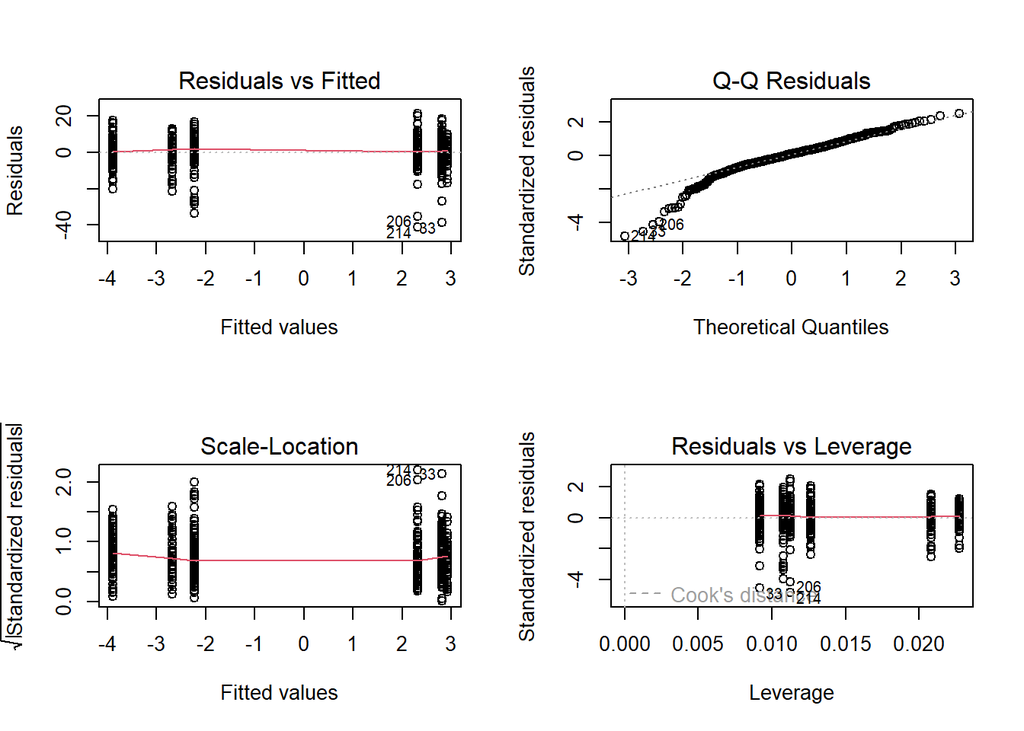

```r
# Ajustement du modèle ANOVA
modele_complet <- aov(ecart_MVPA ~ gender + IPS_categorie + gender:IPS_categorie,contrasts = list(gender = contr.sum,IPS_categorie = contr.sum), data = data_2)

# Résumé du modèle
par(mfrow = c(2,2))
plot(modele_complet)
```

```r
# Diagnostic des résidus
# Test de normalité des résidus
#residus <- residuals(modele_complet)
#shapiro_test <- shapiro.test(residus)
#print(shapiro_test)

# Test d'homogénéité des variances
#levene_test <- leveneTest(residus, data_2$IPS_categorie)  # Assurez-vous de remplacer 'CA' par la variable de groupement appropriée
#print(levene_test)
```

Le graphique en haut à gauche, qui représente en abscisse les valeurs prédites et en ordonnée les résidus permet de vérifier que la variance des résidus est similaire dans tous les groupes. Le graphique du QQ-plot, permet de vérifier que l’hypothèse de normalité des résidus est raisonnable.

Avec ces hypothèses validées nous pouvons regarder les tests.

```r
Anova(modele_complet,type='II')
```

```
## Anova Table (Type II tests)
##
## Response: ecart_MVPA
##                      Sum Sq  Df F value    Pr(>F)
## gender                 3610   1 49.5860 7.028e-12 ***
## IPS_categorie            31   2  0.2152    0.8064
## gender:IPS_categorie    107   2  0.7349    0.4801
## Residuals             33199 456
## ---
## Signif. codes:  0 '***' 0.001 '**' 0.01 '*' 0.05 '.' 0.1 ' ' 1
```

### Modèle traité (pour confirmation de l’hypothèse de difference d’implication des fille et garçon dans le sport)

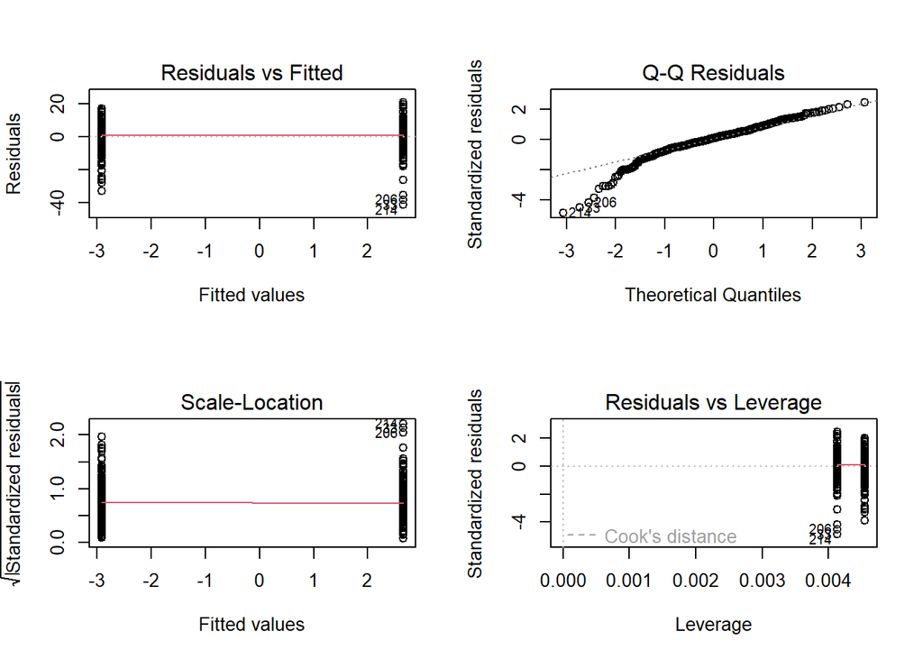

```r
modele = aov(ecart_MVPA ~ gender, data = data_2)
par(mfrow = c(2,2))
plot(modele)
```

Il n’y pas de problème d’égalité de variance ou de normalité sur ce modèle.

En ce qui concerne les tests :

```r
Anova(modele)
```

```
## Anova Table (Type II tests)
##
## Response: ecart_MVPA
##           Sum Sq  Df F value    Pr(>F)
## gender      3579   1  49.381 7.642e-12 ***
## Residuals  33337 460
## ---
## Signif. codes:  0 '***' 0.001 '**' 0.01 '*' 0.05 '.' 0.1 ' ' 1
```

### Test post hoc (Pas important)

```r
lsmeans_results = lsmeans(modele, pairwise ~ gender, adjust='Tukey')
summary(lsmeans_results,infer = c(TRUE, TRUE))
```

```
## $lsmeans
##  gender lsmean    SE  df lower.CL upper.CL t.ratio p.value
##  F       -2.92 0.574 460    -4.05    -1.79  -5.086  <.0001
##  M        2.65 0.547 460     1.58     3.73   4.849  <.0001
##
## Confidence level used: 0.95
##
## $contrasts
##  contrast estimate    SE  df lower.CL upper.CL t.ratio p.value
##  F - M       -5.57 0.793 460    -7.13    -4.01  -7.027  <.0001
##
## Confidence level used: 0.95
```

### Taille d’effet

```r
anova_typeII = Anova(modele)
omega_squared_values = omega_squared(anova_typeII)
```

```
## For one-way between subjects designs, partial omega squared is
##   equivalent to omega squared. Returning omega squared.
```

```r
omega_squared_values
```

```
## # Effect Size for ANOVA
##
## Parameter | Omega2 |       95% CI
## ---------------------------------
## gender    |   0.09 | [0.06, 1.00]
##
## - One-sided CIs: upper bound fixed at [1.00].
```

```r
anova_typeII = Anova(modele_complet,type = "II")
omega_squared_values = omega_squared(anova_typeII,partial = TRUE)
omega_squared_values
```

```
## # Effect Size for ANOVA (Type II)
##
## Parameter            | Omega2 (partial) |       95% CI
## ------------------------------------------------------
## gender               |             0.10 | [0.06, 1.00]
## IPS_categorie        |             0.00 | [0.00, 1.00]
## gender:IPS_categorie |             0.00 | [0.00, 1.00]
##
## - One-sided CIs: upper bound fixed at [1.00].
```

#### Interprétation :

La taille d’effet du facteur genre est important ce qui montre que la différence observé entre les filles et garçons est à prendre en compte dans la pratique.

### 3) Les écarts de MVPA entre filles et garçons selon le milieu géographique (urbain, rural)

#### Selection des colonnes importantes

```r
#Selection des colonnes importantes
data_3 = data %>%
  dplyr::select(gender,ecart_MVPA,Geographie)

#Assurons nous que le types des variables qualitatives sont des facteurs
data_3$gender = as.factor(data_3$gender)
data_3$Geographie = as.factor(data_3$Geographie)

data_3
```

```
## # A tibble: 462 × 3
##    gender ecart_MVPA Geographie
##    <fct>       <dbl> <fct>
##  1 F          -5.28  urbain
##  2 M           3.55  urbain
##  3 M          -1.78  urbain
##  4 F          -7.62  urbain
##  5 M           1.38  urbain
##  6 F          -1.12  urbain
##  7 M          -0.615 urbain
##  8 M           3.38  urbain
##  9 M          20.9   urbain
## 10 F          -0.782 urbain
## # ℹ 452 more rows
```

```r
table(data_3$gender,data_3$Geographie)
```

```
##
##     rural urbain
##   F   101    119
##   M   102    140
```

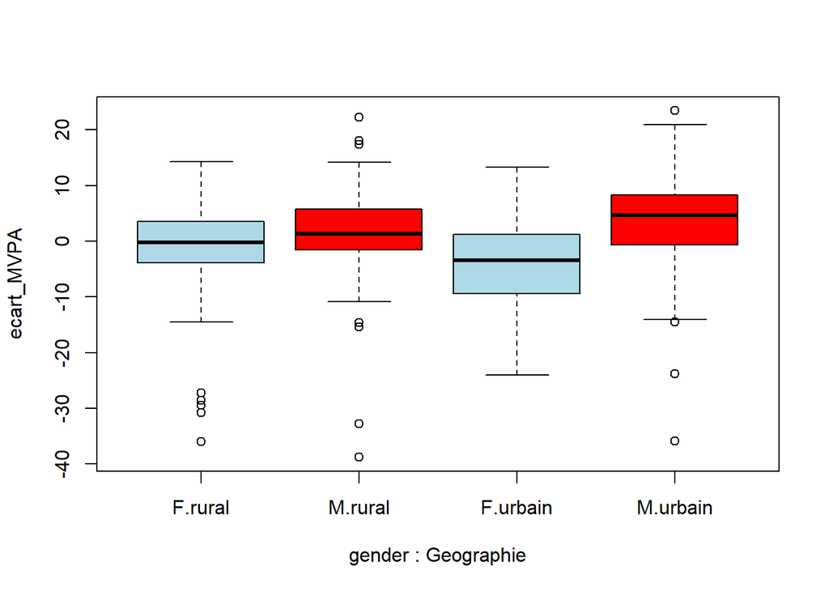

```r
boxplot(ecart_MVPA~gender*Geographie,data=data_3,col=c(rep('lightblue',1),rep('red',1)))
```

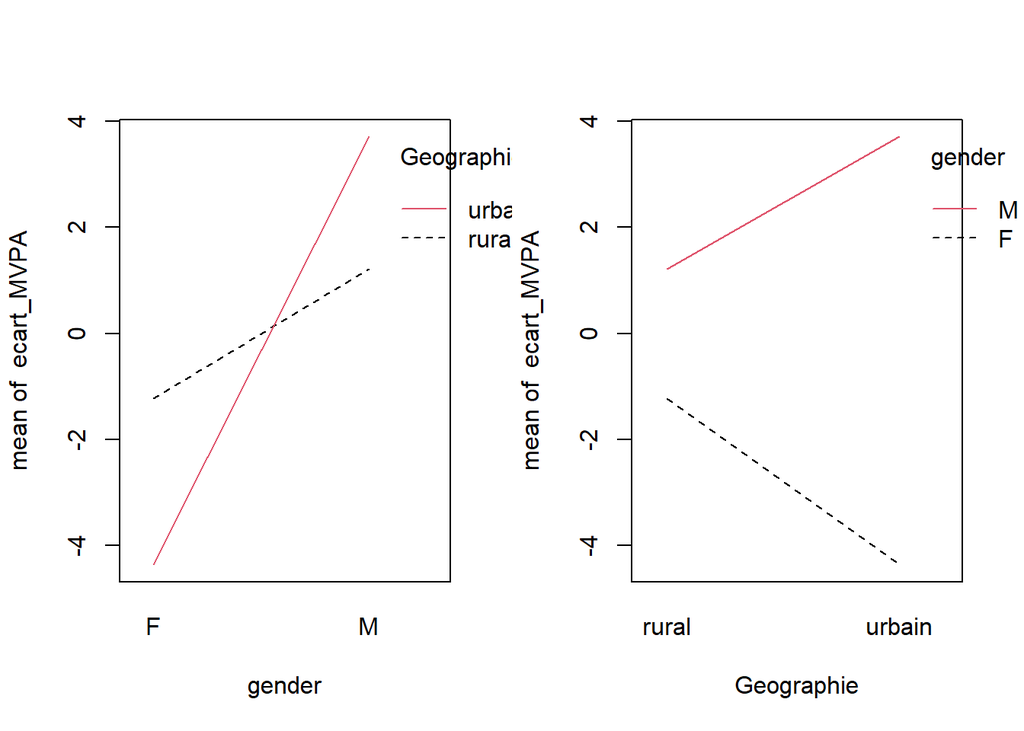

```r
par(mfrow=c(1,2))
with(data_3, interaction.plot(gender,Geographie,ecart_MVPA,col=1:2))
with(data_3, interaction.plot(Geographie,gender,ecart_MVPA,col=1:3))
```

```r
modele_complet_III = AovSum(ecart_MVPA~gender+Geographie+gender:Geographie,data = data_3)
modele_complet_III$Ftest
```

```
##                      SS  df      MS F value    Pr(>F)
## gender             3127   1 3127.17 44.1525 8.645e-11 ***
## Geographie           12   1   11.66  0.1646 0.6851157
## gender:Geographie   893   1  893.44 12.6145 0.0004224 ***
## Residuals         32439 458   70.83
## ---
## Signif. codes:  0 '***' 0.001 '**' 0.01 '*' 0.05 '.' 0.1 ' ' 1
```

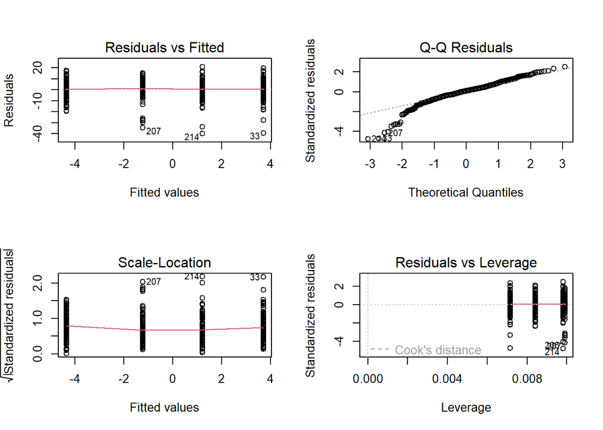

```r
# Ajustement du modèle ANOVA
modele_complet <- aov(ecart_MVPA ~ gender + Geographie + gender:Geographie,contrasts = list(gender = contr.sum,Geographie = contr.sum), data = data_3)

# Résumé du modèle
par(mfrow = c(2,2))
plot(modele_complet)
```

```r
# Diagnostic des résidus
# Test de normalité des résidus
#residus <- residuals(modele_complet)
#shapiro_test <- shapiro.test(residus)
#print(shapiro_test)

# Test d'homogénéité des variances
#levene_test <- leveneTest(residus, data_2$IPS_categorie)  # Assurez-vous de remplacer 'CA' par la variable de groupement appropriée
#print(levene_test)
```

Les hypothèses de normalité et d’égalité semble être validée.

### Test post hoc

```r
lsmeans_results <- lsmeans(modele_complet, pairwise ~ gender:Geographie, adjust='Tukey')

# Affichage des résultats avec les intervalles de confiance
summary(lsmeans_results, infer = c(TRUE, TRUE))
```

```
## $lsmeans
##  gender Geographie lsmean    SE  df lower.CL upper.CL t.ratio p.value
##  F      rural       -1.23 0.837 458   -2.873    0.418  -1.466  0.1433
##  M      rural        1.22 0.833 458   -0.422    2.853   1.459  0.1452
##  F      urbain      -4.35 0.771 458   -5.871   -2.838  -5.644  <.0001
##  M      urbain       3.70 0.711 458    2.304    5.099   5.204  <.0001
##
## Confidence level used: 0.95
##
## $contrasts
##  contrast            estimate   SE  df lower.CL upper.CL t.ratio p.value
##  F rural - M rural      -2.44 1.18 458   -5.490    0.602  -2.068  0.1650
##  F rural - F urbain      3.13 1.14 458    0.191    6.062   2.746  0.0317
##  F rural - M urbain     -4.93 1.10 458   -7.762   -2.096  -4.486  0.0001
##  M rural - F urbain      5.57 1.14 458    2.642    8.498   4.905  <.0001
##  M rural - M urbain     -2.49 1.10 458   -5.310    0.339  -2.269  0.1070
##  F urbain - M urbain    -8.06 1.05 458  -10.761   -5.350  -7.677  <.0001
##
## Confidence level used: 0.95
## Conf-level adjustment: tukey method for comparing a family of 4 estimates
## P value adjustment: tukey method for comparing a family of 4 estimates
```

|  | rural | urbain |  |  |
| --- | --- | --- | --- | --- |
| Ecart entre fille et gaçon des ecarts à la moyenne de mvpa de chaque classe | -2.44 | -8.06 |  |  |
| Intervalle de confiance | -5.49 à 0.602 | -10.761 à -5.350 |  |  |
| P-valeur | 0.1650 | 0.000 |  |  |

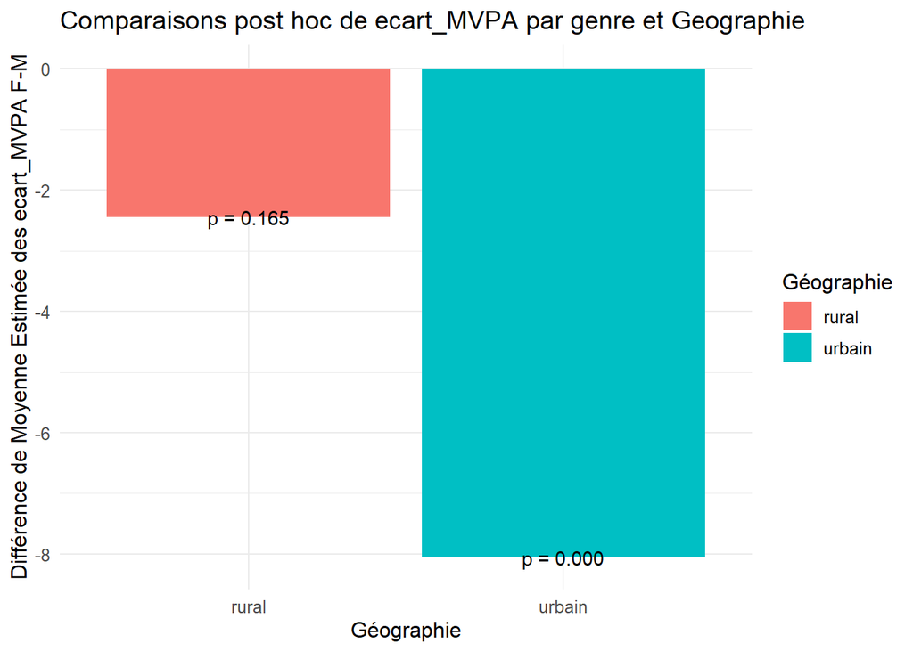

```r
# Calcul des moyennes marginales estimées et des comparaisons post hoc avec correction de Tukey
lsmeans_results <- lsmeans(modele_complet, pairwise ~ gender:Geographie, adjust='Tukey')
summary_data <- summary(lsmeans_results$contrasts)

# Filtrer les contrastes pour ne garder que ceux entre F et M au sein de chaque niveau de géographie
plot_data <- summary_data[summary_data$contrast %in% c("F rural - M rural", "F urbain - M urbain"), ]

# Préparation des données pour le graphique
plot_data <- as.data.frame(plot_data[c("contrast", "estimate", "p.value")])
names(plot_data) <- c("Contrast", "Estimate", "P_Value")

# Extraire le niveau de géographie à partir du nom du contraste
plot_data$Geographie <- sub(".* (rural|urbain) -.*", "\\1", plot_data$Contrast)

# Déterminer le décalage pour les étiquettes textuelles
max_estimate <- max(plot_data$Estimate) * 0.05

# Création du barplot avec légende pour les niveaux de géographie
p <- ggplot(plot_data, aes(x = Geographie, y = Estimate, fill = Geographie)) +
  geom_bar(stat = "identity", position = position_dodge()) +
  geom_text(aes(label = sprintf("p = %.3f", P_Value),
                y = Estimate + max_estimate),  # Utilisation de la variable calculée hors de aes()
            position = position_dodge(width = 0.99), vjust = 0) +
  labs(title = "Comparaisons post hoc de ecart_MVPA par genre et Geographie",
       x = "Géographie",
       y = "Différence de Moyenne Estimée des ecart_MVPA F-M",
       fill = "Géographie") +  # Ajout de la légende
  theme_minimal() +
  theme(text = element_text(size=12))

print(p)
```

On remarque un écart significatif entre les écarts de mvpa à la moyenne de chaque classe des filles et garcons dans le milieu urbain avec une p-valeur inférieur au seuil de 5%. Donc dans le milieu urbain en moyenne les écarts à la moyenne de chaque classe des garçons est plus élevé que celui des filles par contre cette différence entre la moyenne des écarts n’est pas significatif dans le milieu rural.

```r
anova_typeIII = Anova(modele_complet,type = "III")
omega_squared_values = omega_squared(anova_typeIII,partial = TRUE,ci=0.95)
```

```
## Type 3 ANOVAs only give sensible and informative results when covariates
##   are mean-centered and factors are coded with orthogonal contrasts (such
##   as those produced by `contr.sum`, `contr.poly`, or `contr.helmert`, but
##   *not* by the default `contr.treatment`).
```

```r
omega_squared_values
```

```
## # Effect Size for ANOVA (Type III)
##
## Parameter         | Omega2 (partial) |       95% CI
## ---------------------------------------------------
## gender            |             0.09 | [0.05, 1.00]
## Geographie        |             0.00 | [0.00, 1.00]
## gender:Geographie |             0.02 | [0.01, 1.00]
##
## - One-sided CIs: upper bound fixed at [1.00].
```

```r
#Les intervalles de confiance sont unilatérals
```

- La taille d’effet pour le facteur gender est 0.09 ce qui signifie que 9% de la variance totale de la variable dépendante(ecart_mvpa) peut être attribuée à l’effet du genre.
- La taille d’effet pour le facteur Geographie est 0 ce qui signifie que 0% de la variance totale de la variable dépendante(ecart_mvpa) peut être attribuée à l’effet du Geographie .
- La taille d’effet pour l’intercation entre genre et Geographie est 0.02 ce qui signifie que 2% de la variance totale de la variable dépendante(ecart_mvpa) peut être attribuée à l’effet de l’interaction.

### La puissance des test de significativité des facteurs

Ici on ne s’interresse qu’au cas de l’interaction (Test de significativité de l’interaction) car on veut les écarts de mvpa en tre fille et garçon selon la géographie.

```r
taille_effet = omega_squared_values$Omega2_partial
f_square = taille_effet/(1-taille_effet)#utiliser car indépendant de la taille de l'échantillon.

nbr_modalite_interaction = length(unique(data_3$gender))*length(unique(data_3$Geographie))#Nombre total de modalité
effectif_groupe_moyen = nrow(data_3)/nbr_modalite_interaction

puissance = pwr.anova.test(nbr_modalite_interaction,f=sqrt(f_square[3]),sig.level = 0.05,power = NULL,n=effectif_groupe_moyen)

puissance
```

```
##
##      Balanced one-way analysis of variance power calculation
##
##               k = 4
##               n = 115.5
##               f = 0.1585547
##       sig.level = 0.05
##           power = 0.8233953
##
## NOTE: n is number in each group
```

Si on a en moyenne 116 effectifs par groupe j’ai 82% de chance de detecter un effet significatif de l’interaction.

### Taille d’échantillon requise pour détecter un effet avec une proba de 80%

```r
taille_echantillon = pwr.anova.test(nbr_modalite_interaction,f=sqrt(f_square[3]),sig.level = 0.05,power = 0.8)
taille_echantillon
```

```
##
##      Balanced one-way analysis of variance power calculation
##
##               k = 4
##               n = 109.402
##               f = 0.1585547
##       sig.level = 0.05
##           power = 0.8
##
## NOTE: n is number in each group
```

Avec un effectif de 110 par groupe on pourrai à 80% détecter un effet significatif de l’interaction.

Nos données sont assez raisonnable de ce point de vue.

### 4) Les écarts de MVPA entre filles et garçons selon le csp des parents :

```r
data_4 = filter(data,CSP_père != "NA" & CSP_mère != "NA")
#Selection des colonnes importantes
data_4 = data_4 %>%
  dplyr::select(gender,ecart_MVPA,CSP_père,CSP_mère) %>%
  filter(CSP_père != "Agriculteurs exploitants" & CSP_mère != "Agriculteurs exploitants" | CSP_père != "Retraites"  & CSP_mère != "Retraites") #soustraction des CSP dont on a pas suffisemment d'effectif

#Assurons nous que le types des variables qualitatives sont des facteurs
data_4$gender = as.factor(data_4$gender)
data_4$CSP_père = as.factor(data_4$CSP_père)
data_4$CSP_mère = as.factor(data_4$CSP_mère)

#data_4 = filter(data_4,is.na(CSP_père)!= TRUE & is.na(CSP_mère)!=TRUE)
data_4
```

```
## # A tibble: 345 × 4
##    gender ecart_MVPA CSP_père                                          CSP_mère
##    <fct>       <dbl> <fct>                                             <fct>
##  1 F           -5.28 Employes                                          Ouvriers
##  2 M            3.55 Employes                                          Employes
##  3 M           -1.78 Ouvriers                                          Employes
##  4 F           -7.62 Professions intermediaires                        Artisans…
##  5 M            1.38 Autres personnes sans activite professionnelle    Ouvriers
##  6 F           -1.12 Autres personnes sans activite professionnelle    Ouvriers
##  7 M            3.38 Employes                                          Employes
##  8 F           -8.28 Autres personnes sans activite professionnelle    Ouvriers
##  9 F           -9.28 Autres personnes sans activite professionnelle    Employes
## 10 M            6.52 Cadres et professions intellectuelles superieures Employes
## # ℹ 335 more rows
```

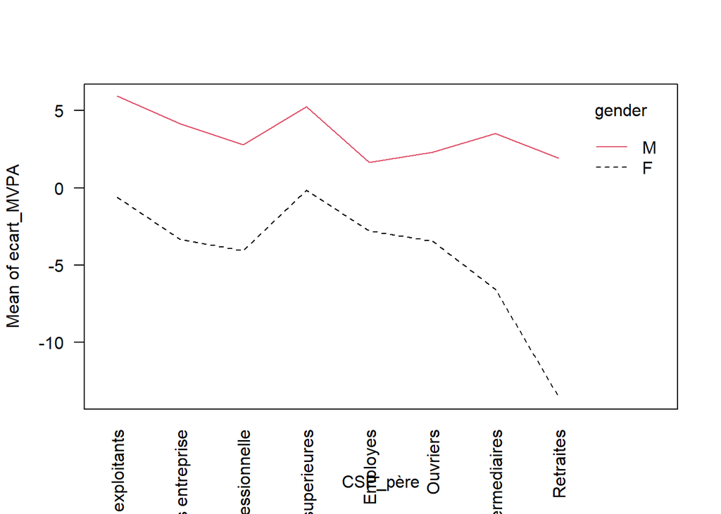

```r
#par(mfrow=c(1,2))
#with(data_4, interaction.plot(gender,CSP_père,ecart_MVPA,col=1:8))
with(data_4, interaction.plot(
  x.factor = CSP_père,
  trace.factor = gender,
  response = ecart_MVPA,
  col = 1:3,
  xlab = "CSP_père",
  ylab = "Mean of ecart_MVPA",
  las = 2  # Incliner les étiquettes des axes
))
```

```r
modele_complet_III = AovSum(ecart_MVPA~ gender + CSP_mère + gender:CSP_père,data = data_4)

modele_complet_III$Ftest
```

```
##                      SS  df      MS F value   Pr(>F)
## gender           1376.7   1 1376.71 17.9458 2.97e-05 ***
## CSP_mère          692.3   7   98.90  1.2892   0.2549
## gender:CSP_père  1015.8  14   72.56  0.9458   0.5096
## Residuals       24702.2 322   76.71
## ---
## Signif. codes:  0 '***' 0.001 '**' 0.01 '*' 0.05 '.' 0.1 ' ' 1
```